# clustering_mixed_method_topography

2024-02-26

# Load Data

```r
mydata <- import("C:/Users/USER ID/Downloads/clustering_mixed_method_topography.xlsx")
# Check missing data
sapply(mydata, function(x) sum(is.na(mydata)))
```

```
##          ADM0_EN             date          validOn         PROVINCE
##                0                0                0                0
##        Kabupaten              lat             long  status_landform
##                0                0                0                0
## status_ecoregion median_elevation     median_slope median_hillshade
##                0                0                0                0
##    median_aspect
##                0
```

```r
rownames(mydata) <- mydata$Kabupaten
data <- mydata %>%
  select(lat, long, status_landform, status_ecoregion, median_elevation, median_slope, median_hillshade, median_aspect)

# Menggunakan factor untuk encoding kategori
## kategori_landform: 1 = lower slope; 2 = upper slope
## kategori_ecoregion: 1 = vulkanik; 2 = fluvial; 3 = struktural
data$kategori_landform <- as.numeric(factor(data$status_landform, levels = unique(data$status_landform)))
data$kategori_ecoregion <- as.numeric(factor(data$status_ecoregion, levels = unique(data$status_ecoregion)))

ready_data <- data %>%
  select(lat, long, kategori_landform, kategori_ecoregion, median_elevation, median_slope, median_hillshade, median_aspect)

dataset <- ready_data[,-c(1,2,3,4)]
```

# Evaluate data

## Uji bartlett’s test of sphericity

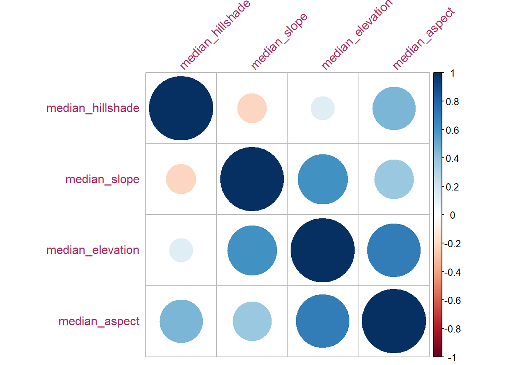

```r
corrplot(cor(dataset),
         order = "hclust",
         tl.col = "maroon",
         tl.srt = 45,
         method="circle")
```

```r
bart_spher(dataset) # p-value < 0.05, maka terdapat multikolinearitas (sehingga perlu dilakukan PCA)
```

```
##  Bartlett's Test of Sphericity
##
## Call: bart_spher(x = dataset)
##
##      X2 = 38.354
##      df = 6
## p-value < 2.22e-16
```

## Uji KMO

```r
# Uji kelayakan data untuk analisis faktor
# KMO(dataset)
KMOS(dataset)
```

```
##
## Kaiser-Meyer-Olkin Statistics
##
## Call: KMOS(x = dataset)
##
## Measures of Sampling Adequacy (MSA):
## median_elevation     median_slope median_hillshade    median_aspect
##        0.6194764        0.5950972        0.3905846        0.5763313
##
## KMO-Criterion: 0.5650083
```

# Eksplorasi data

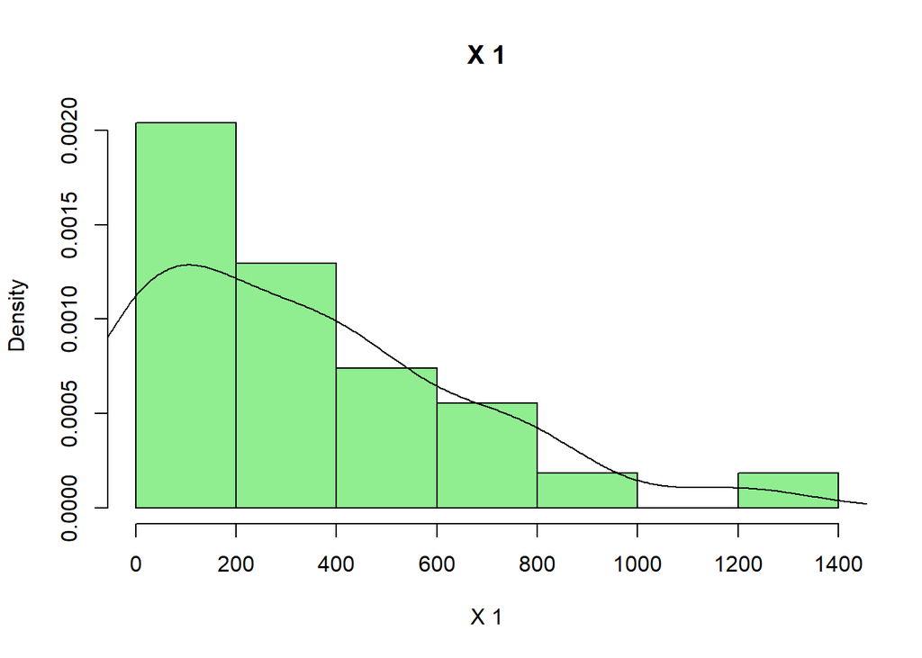

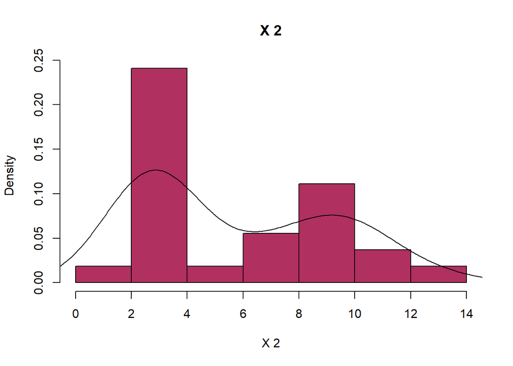

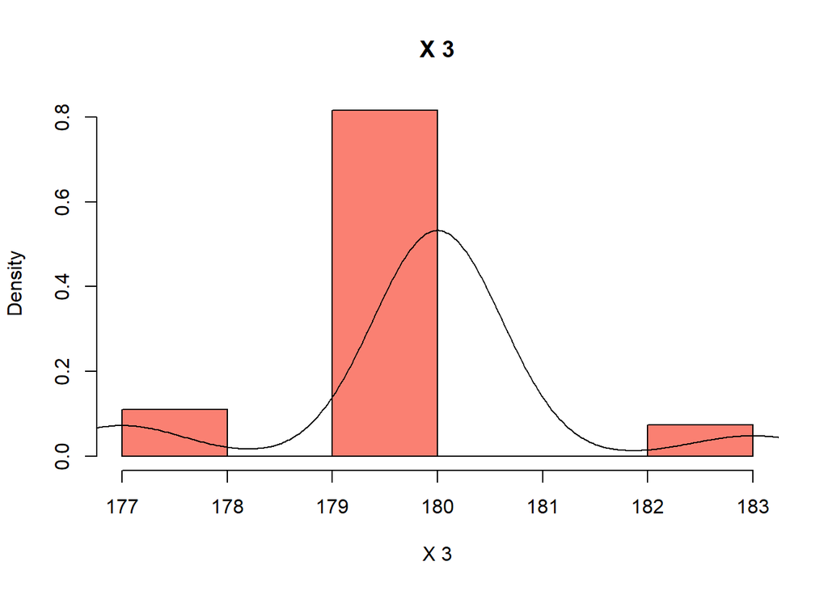

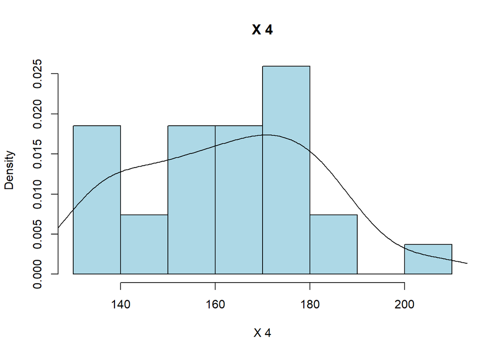

```r
color <- c("lightgreen","maroon","salmon","lightblue","lightyellow","brown")
for(i in 1:ncol(dataset)){
  hist(dataset[,i], prob=T, main=paste("X",i), xlab= paste("X",i),col=color[i])
  lines(density(dataset[,i]))
}
```

## Standarisasi data

```r
sc_data <- scale(dataset)
```

# PCA (Principal Component Analysis) untuk mentreatment data yang mengandung multikolinearitas

```r
PCA <- prcomp(sc_data)
# screeplot(PCA, axisLabSize = 18, titleLabSize = 22)

eigen_value <- get_eigenvalue(PCA)
eigen_value
```

```
##       eigenvalue variance.percent cumulative.variance.percent
## Dim.1  2.1807608        54.519019                    54.51902
## Dim.2  1.2735517        31.838793                    86.35781
## Dim.3  0.3220116         8.050291                    94.40810
## Dim.4  0.2236759         5.591897                   100.00000
```

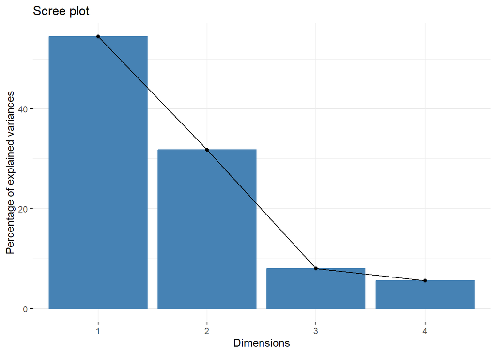

```r
fviz_eig(PCA) #visualisasi
```

```r
PCA$rotation #loading factor
```

```
##                         PC1        PC2        PC3        PC4
## median_elevation -0.6163169  0.1243318 -0.4121347  0.6594240
## median_slope     -0.4672783  0.5358052  0.6956738 -0.1029653
## median_hillshade -0.2155669 -0.7930509  0.5050395  0.2636972
## median_aspect    -0.5961002 -0.2617721 -0.3018577 -0.6964351
```

```r
PCA_scores<-PCA$x[,1:3]
PCA_scores
```

```
##                          PC1         PC2         PC3
## Bandung          -2.86179199  0.71050404 -0.52052425
## Bandung Barat    -2.95453318 -1.25789640  1.17965434
## Bekasi            1.60561638 -0.53305643 -0.01129065
## Bogor            -0.21517869  0.08099699  0.32310634
## Ciamis           -0.50559775  0.33144265  0.56553025
## Cianjur          -1.29292433  0.63320935  0.63341060
## Cirebon           1.94857584 -0.37681863  0.16372552
## Garut            -2.40348161  0.97048093  0.59064463
## Indramayu         1.98715583 -0.41306740  0.12590299
## Karawang          1.95150693 -0.37847057  0.16533720
## Kota Bandung     -0.86207637 -0.63278342 -1.32927963
## Kota Banjar       0.50979477 -0.42626224  0.12005640
## Kota Bekasi       1.27650816 -0.53684728 -0.03339684
## Kota Bogor        0.35409566 -0.61250241 -0.48004317
## Kota Cimahi      -1.19468063 -0.65318381 -1.43141328
## Kota Cirebon      1.88015830 -0.29295783  0.27812823
## Kota Depok        1.12101156 -0.46646600 -0.04860761
## Kota Sukabumi    -1.91297172 -2.82282354 -0.31897361
## Kota Tasikmalaya  0.36316381 -0.23441504 -0.24576121
## Kuningan          0.67576806  2.47944938 -0.25312328
## Majalengka        0.02811576 -0.64412905 -0.34987801
## Pangandaran      -0.05905147 -0.01583839  0.50774305
## Purwakarta        0.38694030  0.14639479  0.52106488
## Subang            1.66994360 -0.27857407  0.24280326
## Sukabumi         -1.29286742  0.31083988  0.33875080
## Sumedang          0.03716418  2.47915297 -0.40574432
## Tasikmalaya      -0.24036399  2.43362152 -0.32782264
```

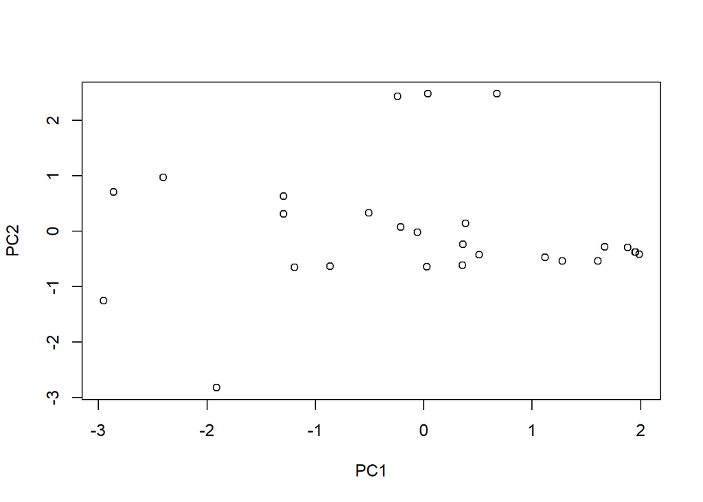

```r
plot(PCA_scores)
```

```r
bart_spher(PCA_scores)
```

```
##  Bartlett's Test of Sphericity
##
## Call: bart_spher(x = PCA_scores)
##
##      X2 = 0
##      df = 3
## p-value = 1
```

## Standarisasi Data

*ket : Perlu dilakukan standarisasi dikarenakan satuan tiap variabel berbeda-beda*

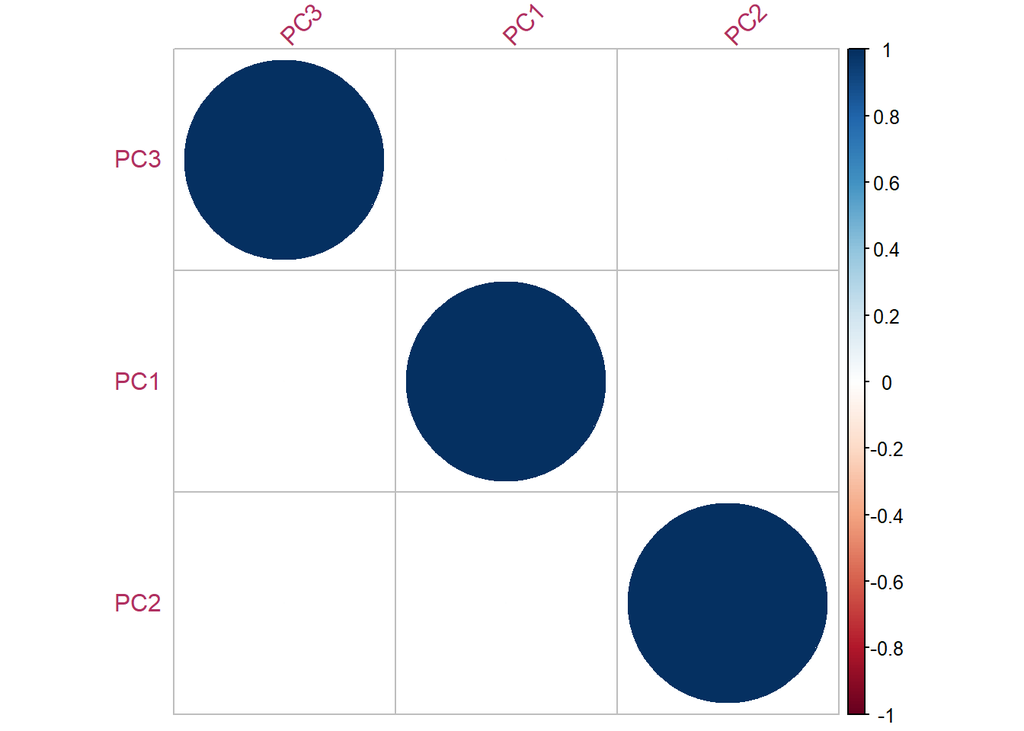

```r
# dataset <- ready_data[,-c(1,2)]
corrplot(cor(PCA_scores),
         order = "hclust",
         tl.col = "maroon",
         tl.srt = 45,
         method="circle")
```

## K-MEANS CLUSTERING

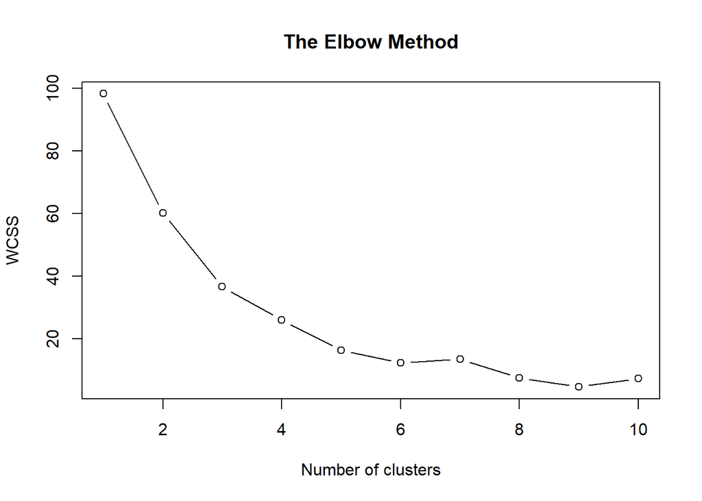

```r
set.seed(12345)
wcss = vector()
for (i in 1:10) wcss[i] = sum(kmeans(PCA_scores, i)$withinss)
plot(1:10,
     wcss,
     type = 'b',
     main = paste('The Elbow Method'),
     xlab = 'Number of clusters',
     ylab = 'WCSS')
```

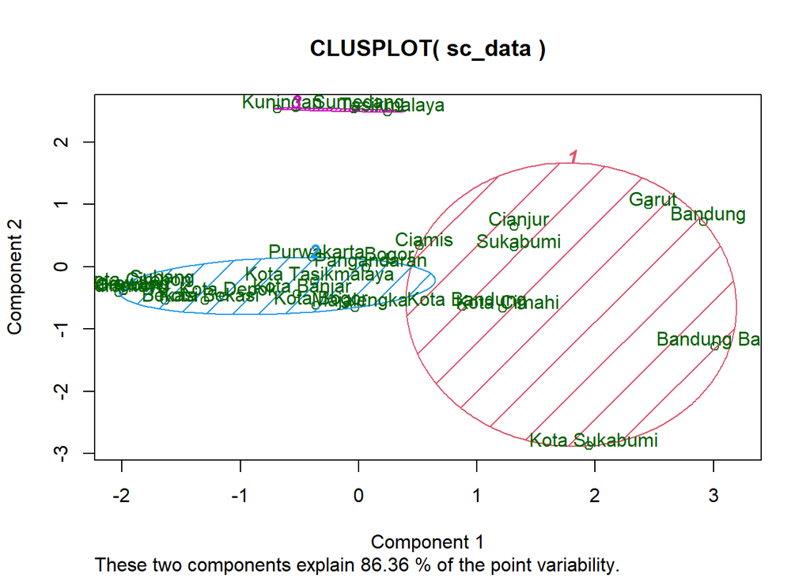

```r
# Fitting K-Means to the dataset
k_means = kmeans(x = PCA_scores, centers = 3)
y_kmeans = k_means$cluster

# Visualising the clusters
library(cluster)
clusplot(sc_data,
         y_kmeans,
         lines = 0,
         shade = TRUE,
         color = TRUE,
         labels = 2,
         plotchar = FALSE,
         span = TRUE)
```

### Visualisasi

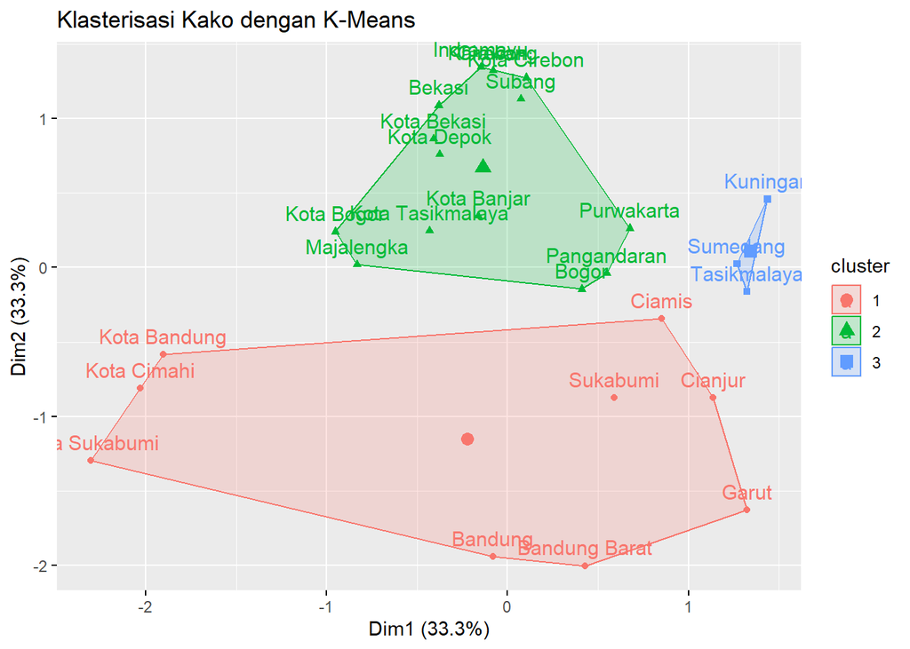

```r
fviz_cluster(k_means, PCA_scores, ellipse.type = "convex", main = "Klasterisasi Kako dengan K-Means")
```

### Evaluasi jumlah cluster

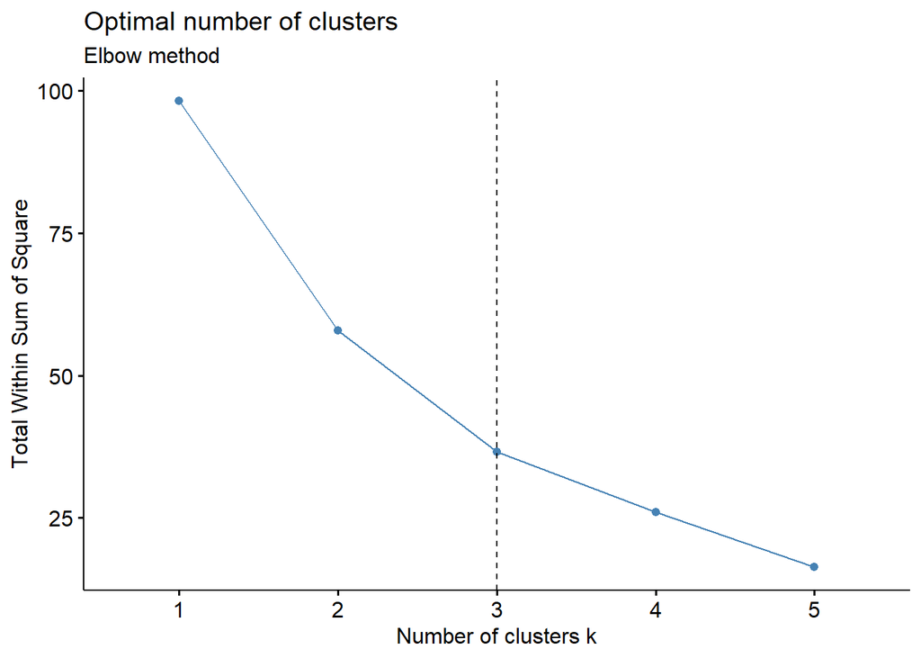

```r
# Optimal number of clusters
library(factoextra)
library(NbClust)

# Elbow method
fviz_nbclust(PCA_scores, kmeans, method = "wss", k.max = 5) +
  geom_vline(xintercept = 3, linetype = 2) + # add line for better visualisation
  labs(subtitle = "Elbow method") # add subtitle
```

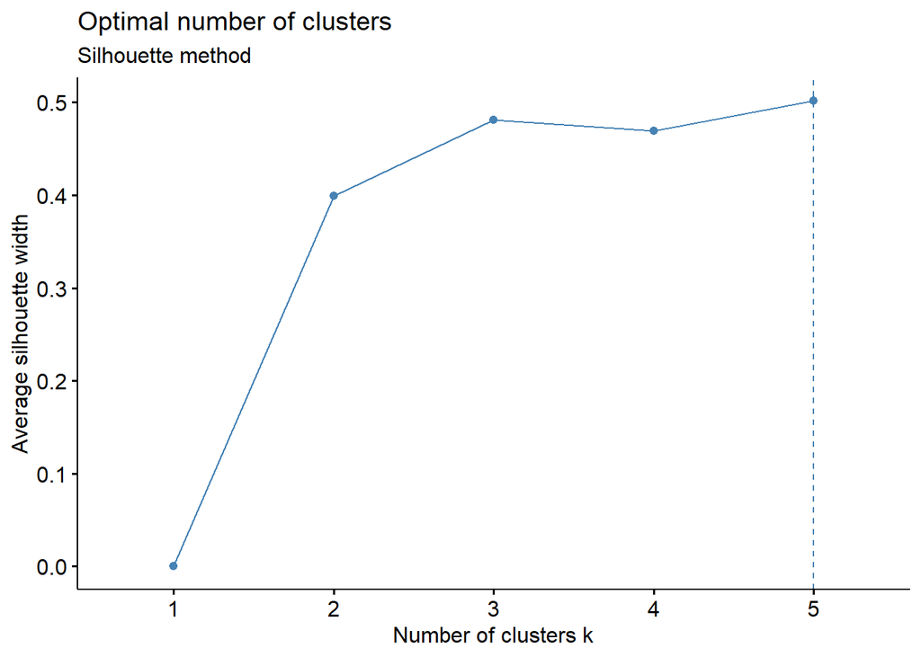

```r
# Silhouette method
fviz_nbclust(PCA_scores, kmeans, method = "silhouette", k.max = 5) +
  labs(subtitle = "Silhouette method")
```

Consensus-based algorithm Because no method is clearly better, a fourth alternative is to run many methods and take the number of clusters that is the most agreed upon (i.e., find the consensus).

```r
#install.packages("parameters")
#install.packages("see")
library(parameters)
library(see)
n_clust <- n_clusters(as.data.frame(PCA_scores), package = c("all"),
                      standardize = FALSE, nbclust_method = "kmeans", n_max = 5)
n_clust
```

```
## # Method Agreement Procedure:
##
## The choice of 5 clusters is supported by 11 (36.67%) methods out of 30 (Gap_Dudoit2002, kl, Ch, Hartigan, CCC, Scott, Friedman, DB, Dunn, SDbw, Mixture (VEV)).
```

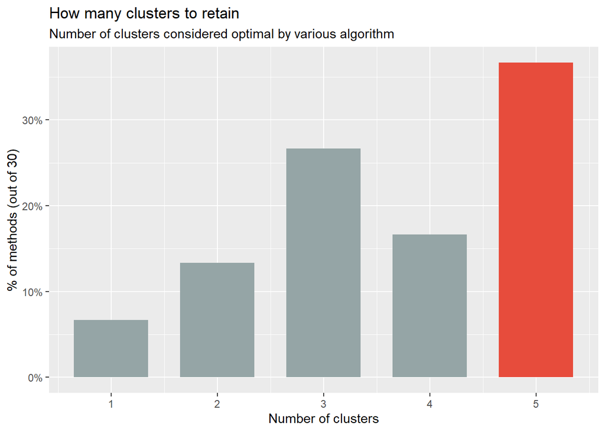

```r
plot(n_clust)
```

#### k = 3

```
##   cluster size ave.sil.width
## 1       1    3          0.80
## 2       2    9          0.19
## 3       3   15          0.59
```

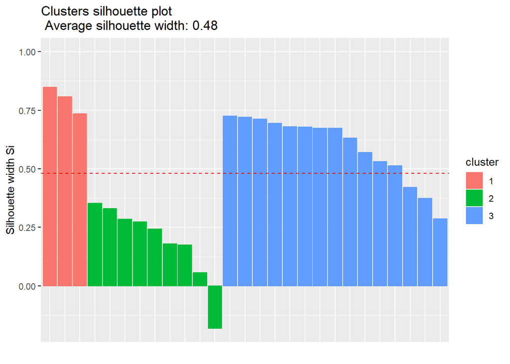

```r
library(cluster)
km_res1 <- kmeans(PCA_scores, centers = 3, nstart = 20)
#?kmeans
sil <- silhouette(km_res1$cluster, dist(PCA_scores))
fviz_silhouette(sil)
```

```r
set.seed(42)
data_kmeans_k3 <- mydata %>% bind_cols(km_res1$cluster)
```

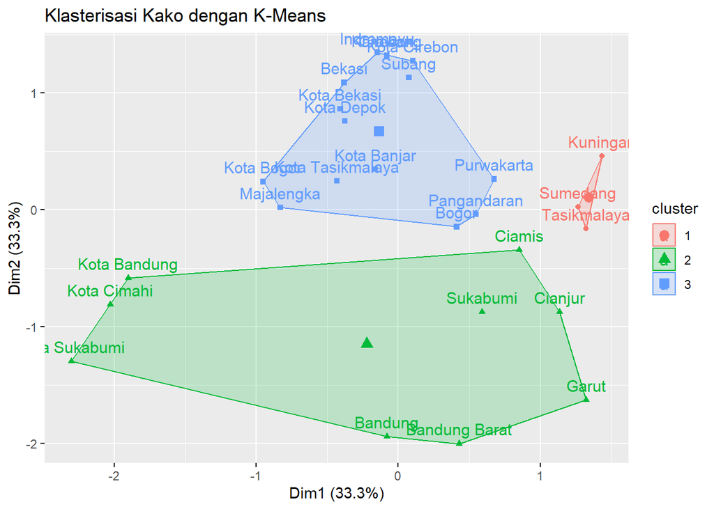

```r
names(data_kmeans_k3)[14] <- "cluster"
fviz_cluster(km_res1, PCA_scores, ellipse.type = "convex", main = "Klasterisasi Kako dengan K-Means")
```

#### k = 5

```
##   cluster size ave.sil.width
## 1       1    8          0.45
## 2       2    3          0.77
## 3       3    5          0.22
## 4       4    8          0.71
## 5       5    3          0.26
```

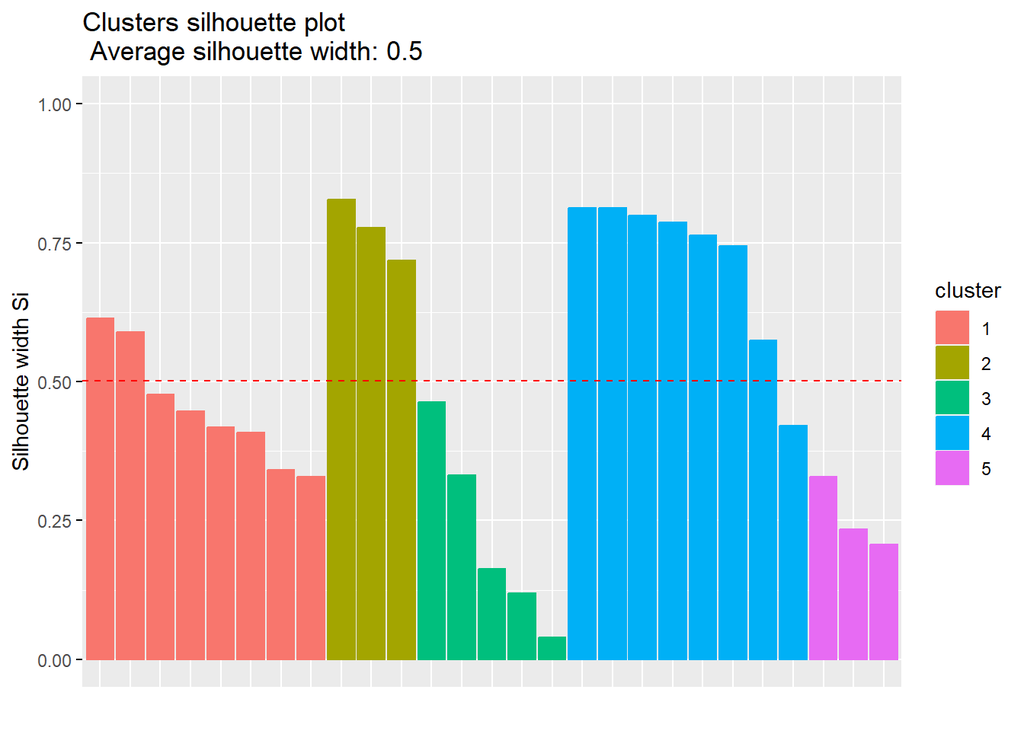

```r
set.seed(42)
km_res2 <- kmeans(PCA_scores, centers = 5, nstart = 20)
#?kmeans
sil2 <- silhouette(km_res2$cluster, dist(PCA_scores))
fviz_silhouette(sil2)
```

```r
data_kmeans_k5 <- mydata %>% bind_cols(km_res2$cluster)
```

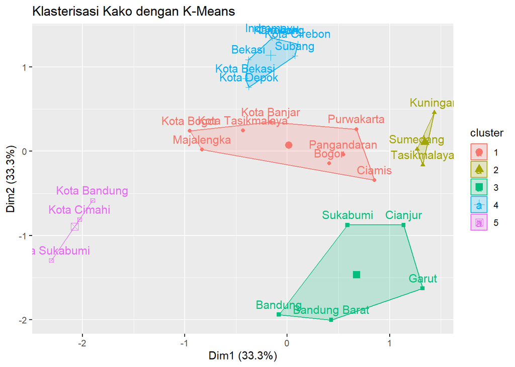

```r
names(data_kmeans_k5)[14] <- "cluster"
fviz_cluster(km_res2, PCA_scores, ellipse.type = "convex", main = "Klasterisasi Kako dengan K-Means")
```

As a reminder, the interpretation of the silhouette coefficient is as follows: if > 0 means that the observation is well grouped. The closer the coefficient is to 1, the better the observation is grouped. if < 0 means that the observation has been placed in the wrong cluster. if = 0 means that the observation is between two clusters.

```r
# set.seed(42)
# km_res3 <- kmeans(sc_data, centers = 4, nstart = 20)
# #?kmeans
# sil3 <- silhouette(km_res3$cluster, dist(sc_data))
# fviz_silhouette(sil3)
```

```r
# data_kmeans_k4 <- cbind(mydata, km_res3$cluster) %>%
#   rename("cluster" = "km_res3$cluster")
# data_kmeans_k4
# fviz_cluster(km_res3, sc_data, ellipse.type = "convex", main = "Klasterisasi Kako dengan K-Means")
```

## HIERARCHICAL CLUSTERING

### Optimal Jumlah Cluster

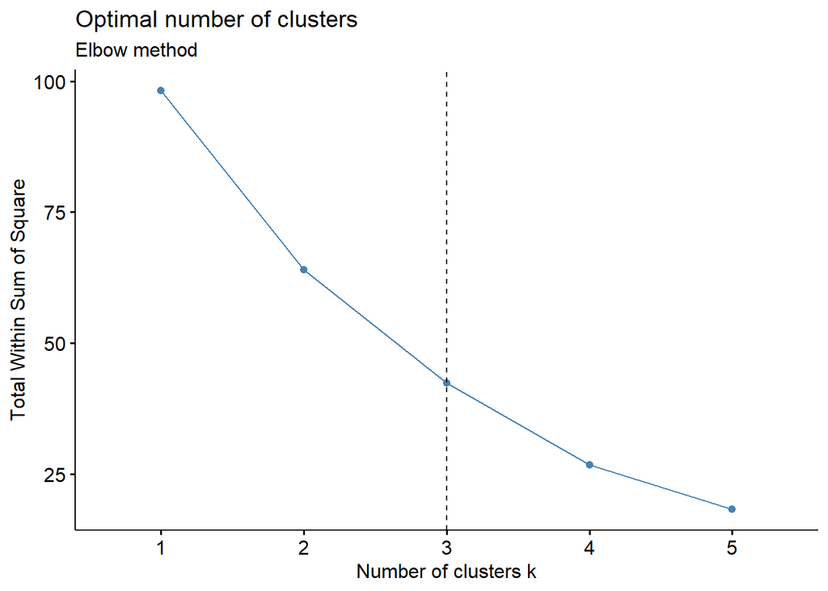

```r
# Elbow method
fviz_nbclust(PCA_scores, hcut, method = "wss", k.max =5) +
  geom_vline(xintercept = 3, linetype = 2) + # add line for better visualisation
  labs(subtitle = "Elbow method") # add subtitle
```

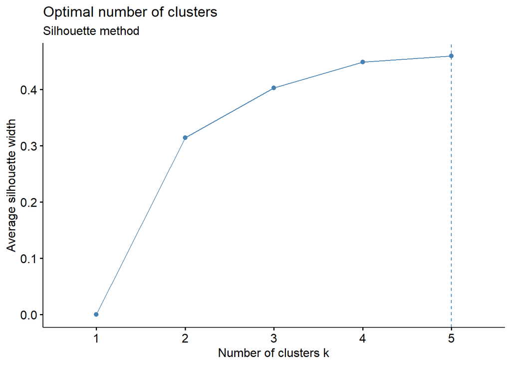

```r
# Silhouette method
fviz_nbclust(PCA_scores, hcut, method = "silhouette", k.max = 5) +
  labs(subtitle = "Silhouette method")
```

There are 5 main methods to measure the distance between clusters, referred as linkage methods: 1. Single linkage: computes the minimum distance between clusters before merging them. 2. Complete linkage: computes the maximum distance between clusters before merging them. 3. Average linkage: computes the average distance between clusters before merging them. 4. Centroid linkage: calculates centroids for both clusters, then computes the distance between the two before merging them. 5. Ward’s (minimum variance) criterion: minimizes the total within-cluster variance and find the pair of clusters that leads to minimum increase in total within-cluster variance after merging.

```r
# Periksa metode hierarti paling optimal melihat nilai agglomerative cluster
linkage_params <- c("single","complete","ward", "average")
names(linkage_params) <- c("single","complete","ward", "average")
ac <- function(x){
  agnes(PCA_scores,method=x)$ac
}
map_dbl(linkage_params,ac)
```

```
##    single  complete      ward   average
## 0.7824481 0.9043822 0.9321960 0.8608648
```

### Single Linkage

```r
# # Hierarchical clustering: single linkage
# hclust <- hclust(dist(sc_data), method = "single")
# #plot(hclust)
#
# fviz_dend(hclust, k = 5,
#           cex = 0.6, palette = "jco",
#           rect = TRUE, rect_border = "jco", rect_fill = TRUE,
#           main = "Cluster Dendogram (Single's Method)")
```

### Average linkage

```r
# # Hierarchical clustering: single linkage
# hclust <- hclust(dist(sc_data), method = "average")
# #plot(hclust)
#
# fviz_dend(hclust, k = 5,
#           cex = 0.6, palette = "jco",
#           rect = TRUE, rect_border = "jco", rect_fill = TRUE,
#           main = "Cluster Dendogram (Average's Method)")
```

### Complete linkage

```r
# # Hierarchical clustering: single linkage
# hclust <- hclust(dist(sc_data), method = "complete")
# #plot(hclust)
#
# fviz_dend(hclust, k = 5,
#           cex = 0.6, palette = "aaas",
#           rect = TRUE, rect_border = "aaas", rect_fill = TRUE,
#           main = "Cluster Dendogram (Complete's Method)")
```

### Ward linkage k = 5

```r
# Hierarchical clustering: ward linkage
hclust <- hclust(dist(PCA_scores), method = "ward.D")
#plot(hclust)
memb5 <- cutree(hclust, k = 5)
data_hcut_5 <- cbind(mydata, memb5)
colnames(data_hcut_5)[14] <- "cluster"

data_hcut_5
```

```
##                    ADM0_EN       date    validOn   PROVINCE        Kabupaten
## Bandung          Indonesia 2019-12-20 2020-04-01 Jawa Barat          Bandung
## Bandung Barat    Indonesia 2019-12-20 2020-04-01 Jawa Barat    Bandung Barat
## Bekasi           Indonesia 2019-12-20 2020-04-01 Jawa Barat           Bekasi
## Bogor            Indonesia 2019-12-20 2020-04-01 Jawa Barat            Bogor
## Ciamis           Indonesia 2019-12-20 2020-04-01 Jawa Barat           Ciamis
## Cianjur          Indonesia 2019-12-20 2020-04-01 Jawa Barat          Cianjur
## Cirebon          Indonesia 2019-12-20 2020-04-01 Jawa Barat          Cirebon
## Garut            Indonesia 2019-12-20 2020-04-01 Jawa Barat            Garut
## Indramayu        Indonesia 2019-12-20 2020-04-01 Jawa Barat        Indramayu
## Karawang         Indonesia 2019-12-20 2020-04-01 Jawa Barat         Karawang
## Kota Bandung     Indonesia 2019-12-20 2020-04-01 Jawa Barat     Kota Bandung
## Kota Banjar      Indonesia 2019-12-20 2020-04-01 Jawa Barat      Kota Banjar
## Kota Bekasi      Indonesia 2019-12-20 2020-04-01 Jawa Barat      Kota Bekasi
## Kota Bogor       Indonesia 2019-12-20 2020-04-01 Jawa Barat       Kota Bogor
## Kota Cimahi      Indonesia 2019-12-20 2020-04-01 Jawa Barat      Kota Cimahi
## Kota Cirebon     Indonesia 2019-12-20 2020-04-01 Jawa Barat     Kota Cirebon
## Kota Depok       Indonesia 2019-12-20 2020-04-01 Jawa Barat       Kota Depok
## Kota Sukabumi    Indonesia 2019-12-20 2020-04-01 Jawa Barat    Kota Sukabumi
## Kota Tasikmalaya Indonesia 2019-12-20 2020-04-01 Jawa Barat Kota Tasikmalaya
## Kuningan         Indonesia 2019-12-20 2020-04-01 Jawa Barat         Kuningan
## Majalengka       Indonesia 2019-12-20 2020-04-01 Jawa Barat       Majalengka
## Pangandaran      Indonesia 2019-12-20 2020-04-01 Jawa Barat      Pangandaran
## Purwakarta       Indonesia 2019-12-20 2020-04-01 Jawa Barat       Purwakarta
## Subang           Indonesia 2019-12-20 2020-04-01 Jawa Barat           Subang
## Sukabumi         Indonesia 2019-12-20 2020-04-01 Jawa Barat         Sukabumi
## Sumedang         Indonesia 2019-12-20 2020-04-01 Jawa Barat         Sumedang
## Tasikmalaya      Indonesia 2019-12-20 2020-04-01 Jawa Barat      Tasikmalaya
##                      lat     long status_landform status_ecoregion
## Bandung          -7.1341 107.6215     Lower Slope         Vulkanik
## Bandung Barat    -6.8652 107.4920     Upper Slope         Vulkanik
## Bekasi           -6.2474 107.1485     Lower Slope          Fluvial
## Bogor            -6.5518 106.6291     Upper Slope         Vulkanik
## Ciamis           -7.3321 108.3493     Upper Slope       Struktural
## Cianjur          -7.3580 107.1957     Upper Slope       Struktural
## Cirebon          -6.6899 108.4751     Lower Slope          Fluvial
## Garut            -7.5012 107.7636     Lower Slope       Struktural
## Indramayu        -6.3373 108.3258     Lower Slope          Fluvial
## Karawang         -6.3227 107.3376     Lower Slope          Fluvial
## Kota Bandung     -6.9175 107.6191     Lower Slope         Vulkanik
```

[output cut: 57 more lines]

```
## Kota Bekasi            3
## Kota Bogor             4
## Kota Cimahi            2
## Kota Cirebon           3
## Kota Depok             3
## Kota Sukabumi          2
## Kota Tasikmalaya       4
## Kuningan               5
## Majalengka             4
## Pangandaran            4
## Purwakarta             4
## Subang                 3
## Sukabumi               1
## Sumedang               5
## Tasikmalaya            5
```

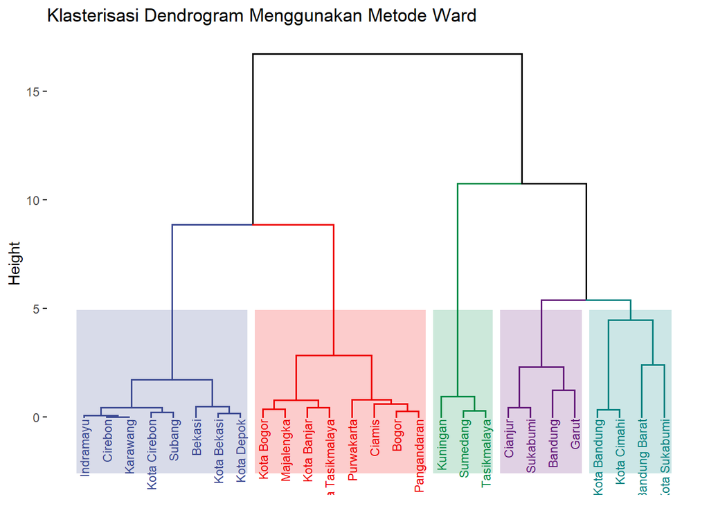

```r
fviz_dend(hclust, k = 5,
          cex = 0.6, palette = "aaas",
          rect = TRUE, rect_border = "aaas", rect_fill = TRUE,
          main = "Klasterisasi Dendrogram Menggunakan Metode Ward")
```

### Ward linkage k = 3

```r
# Hierarchical clustering: single linkage
hclust <- hclust(dist(PCA_scores), method = "ward.D")
#plot(hclust)
memb3 <- cutree(hclust, k = 3)
data_hcut_3 <- cbind(mydata, memb3)
colnames(data_hcut_3)[14] <- "cluster"
data_hcut_3
```

```
##                    ADM0_EN       date    validOn   PROVINCE        Kabupaten
## Bandung          Indonesia 2019-12-20 2020-04-01 Jawa Barat          Bandung
## Bandung Barat    Indonesia 2019-12-20 2020-04-01 Jawa Barat    Bandung Barat
## Bekasi           Indonesia 2019-12-20 2020-04-01 Jawa Barat           Bekasi
## Bogor            Indonesia 2019-12-20 2020-04-01 Jawa Barat            Bogor
## Ciamis           Indonesia 2019-12-20 2020-04-01 Jawa Barat           Ciamis
## Cianjur          Indonesia 2019-12-20 2020-04-01 Jawa Barat          Cianjur
## Cirebon          Indonesia 2019-12-20 2020-04-01 Jawa Barat          Cirebon
## Garut            Indonesia 2019-12-20 2020-04-01 Jawa Barat            Garut
## Indramayu        Indonesia 2019-12-20 2020-04-01 Jawa Barat        Indramayu
## Karawang         Indonesia 2019-12-20 2020-04-01 Jawa Barat         Karawang
## Kota Bandung     Indonesia 2019-12-20 2020-04-01 Jawa Barat     Kota Bandung
## Kota Banjar      Indonesia 2019-12-20 2020-04-01 Jawa Barat      Kota Banjar
## Kota Bekasi      Indonesia 2019-12-20 2020-04-01 Jawa Barat      Kota Bekasi
## Kota Bogor       Indonesia 2019-12-20 2020-04-01 Jawa Barat       Kota Bogor
## Kota Cimahi      Indonesia 2019-12-20 2020-04-01 Jawa Barat      Kota Cimahi
## Kota Cirebon     Indonesia 2019-12-20 2020-04-01 Jawa Barat     Kota Cirebon
## Kota Depok       Indonesia 2019-12-20 2020-04-01 Jawa Barat       Kota Depok
## Kota Sukabumi    Indonesia 2019-12-20 2020-04-01 Jawa Barat    Kota Sukabumi
## Kota Tasikmalaya Indonesia 2019-12-20 2020-04-01 Jawa Barat Kota Tasikmalaya
## Kuningan         Indonesia 2019-12-20 2020-04-01 Jawa Barat         Kuningan
## Majalengka       Indonesia 2019-12-20 2020-04-01 Jawa Barat       Majalengka
## Pangandaran      Indonesia 2019-12-20 2020-04-01 Jawa Barat      Pangandaran
## Purwakarta       Indonesia 2019-12-20 2020-04-01 Jawa Barat       Purwakarta
## Subang           Indonesia 2019-12-20 2020-04-01 Jawa Barat           Subang
## Sukabumi         Indonesia 2019-12-20 2020-04-01 Jawa Barat         Sukabumi
## Sumedang         Indonesia 2019-12-20 2020-04-01 Jawa Barat         Sumedang
## Tasikmalaya      Indonesia 2019-12-20 2020-04-01 Jawa Barat      Tasikmalaya
##                      lat     long status_landform status_ecoregion
## Bandung          -7.1341 107.6215     Lower Slope         Vulkanik
## Bandung Barat    -6.8652 107.4920     Upper Slope         Vulkanik
## Bekasi           -6.2474 107.1485     Lower Slope          Fluvial
## Bogor            -6.5518 106.6291     Upper Slope         Vulkanik
## Ciamis           -7.3321 108.3493     Upper Slope       Struktural
## Cianjur          -7.3580 107.1957     Upper Slope       Struktural
## Cirebon          -6.6899 108.4751     Lower Slope          Fluvial
## Garut            -7.5012 107.7636     Lower Slope       Struktural
## Indramayu        -6.3373 108.3258     Lower Slope          Fluvial
## Karawang         -6.3227 107.3376     Lower Slope          Fluvial
## Kota Bandung     -6.9175 107.6191     Lower Slope         Vulkanik
```

[output cut: 57 more lines]

```
## Kota Bekasi            2
## Kota Bogor             2
## Kota Cimahi            1
## Kota Cirebon           2
## Kota Depok             2
## Kota Sukabumi          1
## Kota Tasikmalaya       2
## Kuningan               3
## Majalengka             2
## Pangandaran            2
## Purwakarta             2
## Subang                 2
## Sukabumi               1
## Sumedang               3
## Tasikmalaya            3
```

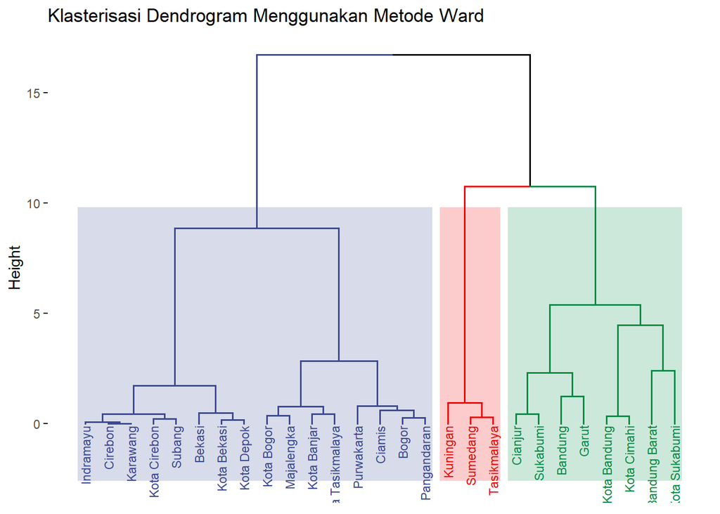

```r
fviz_dend(hclust, k = 3,
          cex = 0.6, palette = "aaas",
          rect = TRUE, rect_border = "aaas", rect_fill = TRUE,
          main = "Klasterisasi Dendrogram Menggunakan Metode Ward")
```

### Validasi Cluster untuk hirarki

#### The internal measures include the connectivity, and Silhouette Width, and Dunn Index. The connectivity indicates the degree of connectedness of the clusters, as determined by the k-nearest neighbors

#### The stability measures are a special version of internal measures which evaluate the stability of a clustering result by comparing it with the clusters obtained by removing one column at a time.

```r
intern <- clValid(PCA_scores, c(3,5), clMethods = c("hierarchical"), validation = "internal")
summary(intern)
```

```
##
## Clustering Methods:
##  hierarchical
##
## Cluster sizes:
##  3 5
##
## Validation Measures:
##                                  3       5
##
## hierarchical Connectivity   9.2365 19.0242
##              Dunn           0.4575  0.3106
##              Silhouette     0.3953  0.4959
##
## Optimal Scores:
##
##              Score  Method       Clusters
## Connectivity 9.2365 hierarchical 3
## Dunn         0.4575 hierarchical 3
## Silhouette   0.4959 hierarchical 5
```

```r
optimalScores(intern)
```

```
##                  Score       Method Clusters
## Connectivity 9.2365079 hierarchical        3
## Dunn         0.4575162 hierarchical        3
## Silhouette   0.4959500 hierarchical        5
```

```r
stab <- clValid(PCA_scores, c(3,5), clMethods = c("hierarchical"), validation = "stability")
summary(stab)
```

```
##
## Clustering Methods:
##  hierarchical
##
## Cluster sizes:
##  3 5
##
## Validation Measures:
##                        3      5
##
## hierarchical APN  0.1740 0.2593
##              AD   1.9141 1.3936
##              ADM  0.7005 0.9226
##              FOM  1.0673 1.0053
##
## Optimal Scores:
##
##     Score  Method       Clusters
## APN 0.1740 hierarchical 3
## AD  1.3936 hierarchical 5
## ADM 0.7005 hierarchical 3
## FOM 1.0053 hierarchical 5
```

```r
optimalScores(stab)
```

```
##         Score       Method Clusters
## APN 0.1739618 hierarchical        3
## AD  1.3936014 hierarchical        5
## ADM 0.7004667 hierarchical        3
## FOM 1.0053231 hierarchical        5
```

## FUZZY C-MEANS

### Optimal Jumlah Cluster

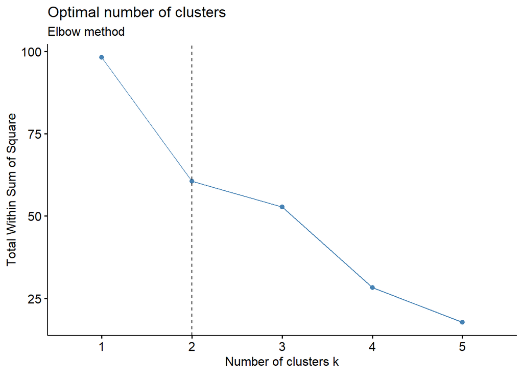

```r
# Elbow method
fviz_nbclust(PCA_scores, fanny, method = "wss", k.max = 5) +
  geom_vline(xintercept = 2, linetype = 2) + # add line for better visualisation
  labs(subtitle = "Elbow method") # add subtitle
```

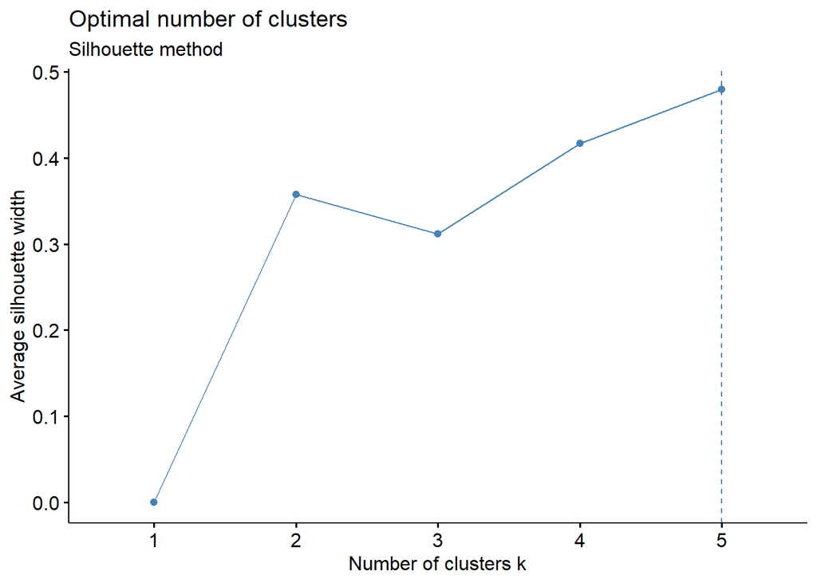

```r
# Silhouette method
fviz_nbclust(PCA_scores, fanny, method = "silhouette", k.max = 5) +
  labs(subtitle = "Silhouette method")
```

### Jumlah cluster = 5

#### Fuzzifier m = 1.5

```r
fcm_1 <- fcm(PCA_scores, centers = 5, m = 1.5)
summary(fcm_1)
```

```
## Summary for 'fcm_1'
##
## Number of data objects:  27
##
## Number of clusters:  5
##
## Crisp clustering vector:
##  [1] 3 3 1 4 4 3 1 3 1 1 2 4 1 4 2 1 1 2 4 5 4 4 4 1 3 5 5
##
## Initial cluster prototypes:
##                  PC1        PC2        PC3
## Cluster 1  1.9871558 -0.4130674  0.1259030
## Cluster 2 -0.8620764 -0.6327834 -1.3292796
## Cluster 3  0.6757681  2.4794494 -0.2531233
## Cluster 4  0.3540957 -0.6125024 -0.4800432
## Cluster 5 -0.2403640  2.4336215 -0.3278226
##
## Final cluster prototypes:
##                   PC1        PC2        PC3
## Cluster 1  1.67932073 -0.4096122  0.1118794
## Cluster 2 -1.35365896 -1.2671712 -0.9790904
## Cluster 3 -2.10329350  0.3981029  0.3858396
## Cluster 4  0.09354259 -0.1794907  0.1243062
## Cluster 5  0.15078127  2.4550178 -0.3267034
##
## Distance between the final cluster prototypes
##           Cluster 1 Cluster 2 Cluster 3 Cluster 4
## Cluster 2 11.124589
## Cluster 3 15.035628  5.198124
## Cluster 4  2.567803  4.494925  5.228103
## Cluster 5 10.734893 16.543640  9.819469  7.147321
##
## Difference between the initial and final cluster prototypes
##                  PC1          PC2          PC3
## Cluster 1 -0.3078351  0.003455205 -0.014023569
## Cluster 2 -0.4915826 -0.634387776  0.350189191
## Cluster 3 -2.7790616 -2.081346509  0.638962867
## Cluster 4 -0.2605531  0.433011695  0.604349411
## Cluster 5  0.3911453  0.021396245  0.001119263
##
```

[output cut: 25 more lines]

```
##
## Dunn's Fuzziness Coefficients:
## dunn_coeff normalized
##  0.9054638  0.8818297
##
## Within cluster sum of squares by cluster:
##         1         2         3         4         5
## 0.9411957 4.5012162 7.3794780 3.0744339 0.4544177
## (between_SS / total_SS =  82.98%)
##
## Available components:
##  [1] "u"          "v"          "v0"         "d"          "x"
##  [6] "cluster"    "csize"      "sumsqrs"    "k"          "m"
## [11] "iter"       "best.start" "func.val"   "comp.time"  "inpargs"
## [16] "algorithm"  "call"
```

#### Visualisasi clustering FCM Cluster = 5; fuzzifier = 1.5

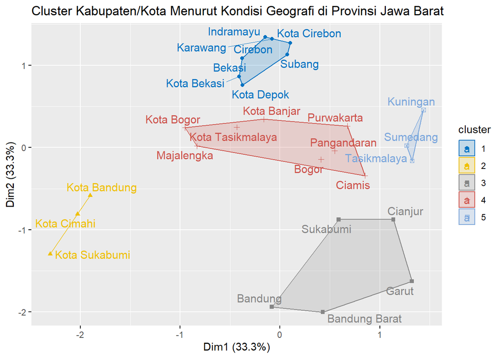

```r
# plotcluster(fcm_1, cp = 1, trans = TRUE)
res.fcm1 <- ppclust2(fcm_1, "fanny")
# res.fcm2

fviz_cluster(res.fcm1, data=PCA_scores, palette="jco", repel=TRUE, main = "Cluster Kabupaten/Kota Menurut Kondisi Geografi di Provinsi Jawa Barat")
```

#### Fuzzifier m = 2

```r
fcm_2 <- fcm(PCA_scores, centers = 5, m = 2)
summary(fcm_2)
```

```
## Summary for 'fcm_2'
##
## Number of data objects:  27
##
## Number of clusters:  5
##
## Crisp clustering vector:
##  [1] 1 5 2 3 3 1 2 1 2 2 3 3 2 3 3 2 2 5 3 4 3 3 3 2 1 4 4
##
## Initial cluster prototypes:
##                   PC1         PC2         PC3
## Cluster 1 -1.29286742  0.31083987  0.33875080
## Cluster 2  1.27650816 -0.53684728 -0.03339684
## Cluster 3 -0.05905147 -0.01583839  0.50774305
## Cluster 4  0.67576806  2.47944938 -0.25312328
## Cluster 5 -2.86179199  0.71050404 -0.52052425
##
## Final cluster prototypes:
##                   PC1        PC2          PC3
## Cluster 1 -1.84759470  0.5148904  0.303441154
## Cluster 2  1.69236428 -0.3987636  0.120502745
## Cluster 3  0.08073803 -0.2440481 -0.002978457
## Cluster 4  0.10300255  2.4102393 -0.332435693
## Cluster 5 -1.98919426 -2.3668418 -0.185820825
##
## Distance between the final cluster prototypes
##           Cluster 1 Cluster 2 Cluster 3 Cluster 4
## Cluster 2 13.399540
## Cluster 3  4.388348  2.636524
## Cluster 4  7.801516 10.621721  7.154279
## Cluster 5  8.563808 17.521039  8.824304 27.219287
##
## Difference between the initial and final cluster prototypes
##                  PC1         PC2         PC3
## Cluster 1 -0.5547273  0.20405053 -0.03530965
## Cluster 2  0.4158561  0.13808367  0.15389959
## Cluster 3  0.1397895 -0.22820969 -0.51072151
## Cluster 4 -0.5727655 -0.06921008 -0.07931241
## Cluster 5  0.8725977 -3.07734581  0.33470342
##
```

[output cut: 25 more lines]

```
##
## Dunn's Fuzziness Coefficients:
## dunn_coeff normalized
##  0.6821684  0.6027105
##
## Within cluster sum of squares by cluster:
##         1         2         3         4         5
## 2.9856334 0.9411957 9.1585530 0.4544177 2.8898665
## (between_SS / total_SS =  82.33%)
##
## Available components:
##  [1] "u"          "v"          "v0"         "d"          "x"
##  [6] "cluster"    "csize"      "sumsqrs"    "k"          "m"
## [11] "iter"       "best.start" "func.val"   "comp.time"  "inpargs"
## [16] "algorithm"  "call"
```

#### Visualisasi clustering FCM Cluster = 5; fuzzifier = 2

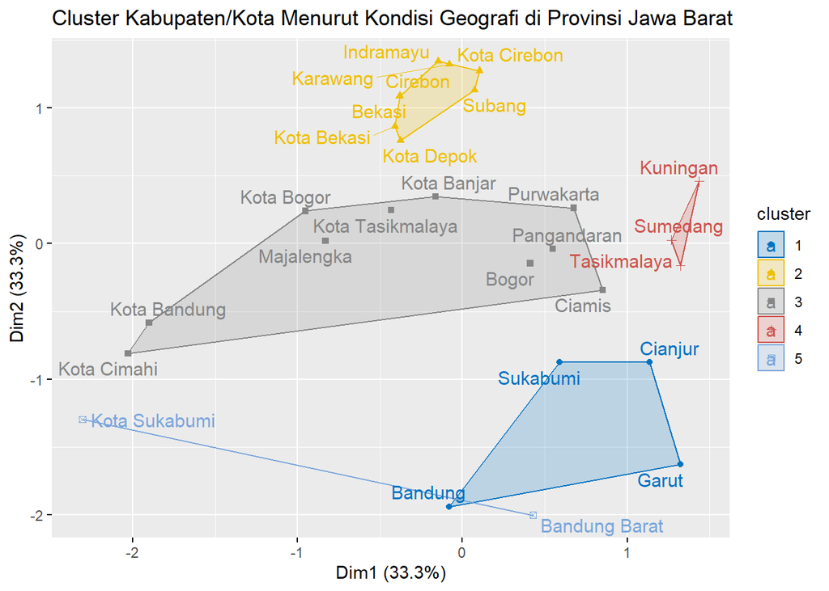

```r
# plotcluster(fcm_2, cp = 1, trans = TRUE)
res.fcm2 <- ppclust2(fcm_2, "fanny")
# res.fcm2

fviz_cluster(res.fcm2, data=PCA_scores, palette="jco", repel=TRUE, main = "Cluster Kabupaten/Kota Menurut Kondisi Geografi di Provinsi Jawa Barat")
```

#### Fuzzifier m = 2.5

```r
fcm_3 <- fcm(PCA_scores, centers = 5, m = 2.5)
summary(fcm_3)
```

```
## Summary for 'fcm_3'
##
## Number of data objects:  27
##
## Number of clusters:  5
##
## Crisp clustering vector:
##  [1] 5 5 4 3 3 5 4 5 4 4 1 3 4 3 1 4 4 1 3 2 3 3 3 4 5 2 2
##
## Initial cluster prototypes:
##                   PC1        PC2         PC3
## Cluster 1 -1.91297172 -2.8228235 -0.31897361
## Cluster 2  0.03716418  2.4791530 -0.40574432
## Cluster 3 -0.50559775  0.3314427  0.56553025
## Cluster 4  1.60561638 -0.5330564 -0.01129065
## Cluster 5 -2.86179199  0.7105040 -0.52052425
##
## Final cluster prototypes:
##                   PC1         PC2        PC3
## Cluster 1 -1.04386106 -0.69949901 -1.2212597
## Cluster 2  0.04453863  2.41042337 -0.3390074
## Cluster 3 -0.06284425 -0.05163704  0.3032147
## Cluster 4  1.72057309 -0.39500921  0.1337633
## Cluster 5 -2.22227570  0.53828261  0.3824889
##
## Distance between the final cluster prototypes
##           Cluster 1 Cluster 2 Cluster 3 Cluster 4
## Cluster 2 11.634600
## Cluster 3  3.706141  6.485722
## Cluster 4  9.570898 10.903056  3.327196
## Cluster 5  5.492774  9.163915  5.017434 16.478955
##
## Difference between the initial and final cluster prototypes
##                   PC1         PC2        PC3
## Cluster 1 0.869110657  2.12332453 -0.9022861
## Cluster 2 0.007374447 -0.06872961  0.0667369
## Cluster 3 0.442753499 -0.38307969 -0.2623156
## Cluster 4 0.114956706  0.13804722  0.1450540
## Cluster 5 0.639516284 -0.17222143  0.9030132
##
```

[output cut: 25 more lines]

```
##
## Dunn's Fuzziness Coefficients:
## dunn_coeff normalized
##  0.5348639  0.4185798
##
## Within cluster sum of squares by cluster:
##         1         2         3         4         5
## 4.5012162 0.4544177 3.0744339 0.9411957 7.3794780
## (between_SS / total_SS =  82.85%)
##
## Available components:
##  [1] "u"          "v"          "v0"         "d"          "x"
##  [6] "cluster"    "csize"      "sumsqrs"    "k"          "m"
## [11] "iter"       "best.start" "func.val"   "comp.time"  "inpargs"
## [16] "algorithm"  "call"
```

#### Visualisasi clustering FCM Cluster = 5; fuzzifier = 2.5

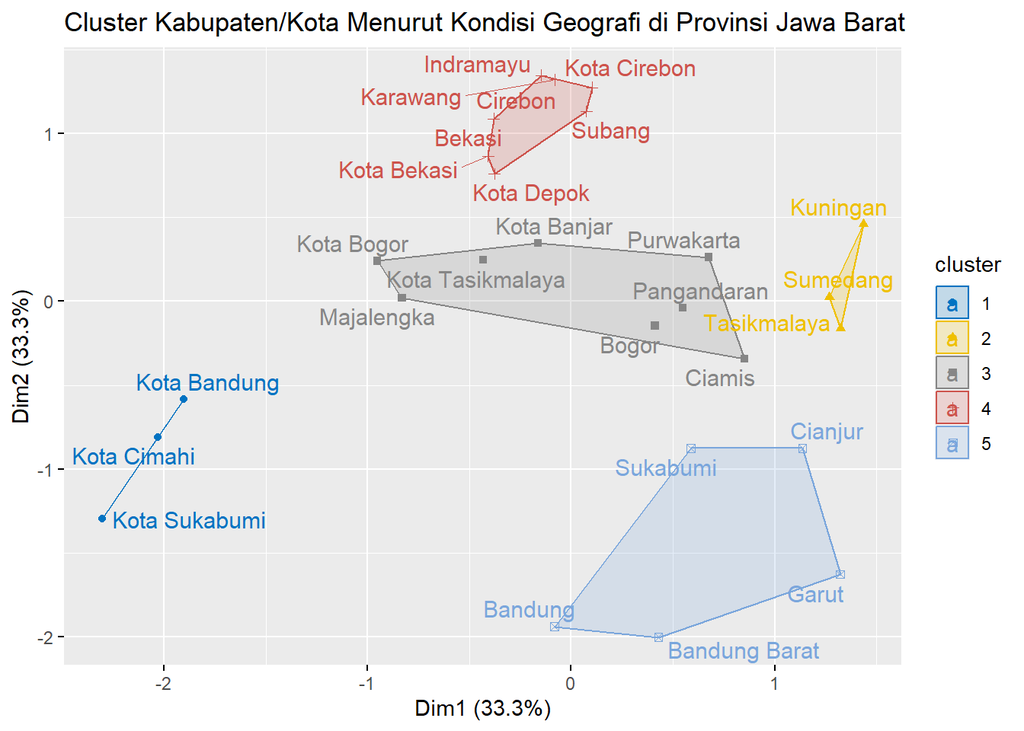

```r
# plotcluster(fcm_3, cp = 1, trans = TRUE)
res.fcm3 <- ppclust2(fcm_3, "fanny")
# res.fcm2

fviz_cluster(res.fcm3, data=PCA_scores, palette="jco", repel=TRUE, main = "Cluster Kabupaten/Kota Menurut Kondisi Geografi di Provinsi Jawa Barat")
```

#### Fuzzifier m = 3

```r
fcm_4 <- fcm(PCA_scores, centers = 5, m = 3)
summary(fcm_4)
```

```
## Summary for 'fcm_4'
##
## Number of data objects:  27
##
## Number of clusters:  5
##
## Crisp clustering vector:
##  [1] 2 2 1 3 3 2 1 2 1 1 4 5 1 5 4 1 1 4 5 3 5 3 3 1 2 3 2
##
## Initial cluster prototypes:
##                   PC1         PC2         PC3
## Cluster 1  1.88015830 -0.29295783  0.27812823
## Cluster 2 -1.29292433  0.63320935  0.63341060
## Cluster 3 -0.05905147 -0.01583839  0.50774305
## Cluster 4 -1.91297172 -2.82282354 -0.31897361
## Cluster 5  1.60561638 -0.53305643 -0.01129065
##
## Final cluster prototypes:
##                  PC1        PC2        PC3
## Cluster 1  1.8186052 -0.3581873  0.1648784
## Cluster 2 -1.4469021  0.5574017  0.4308508
## Cluster 3 -0.2362488  0.1501578  0.3528605
## Cluster 4 -1.0789571 -0.6169543 -1.2750609
## Cluster 5  0.3215906 -0.2809354 -0.1991088
##
## Distance between the final cluster prototypes
##            Cluster 1  Cluster 2  Cluster 3  Cluster 4
## Cluster 2 11.5725828
## Cluster 3  4.5161772  1.6376115
## Cluster 4 10.5362528  4.4246303  3.9487464
## Cluster 5  2.3795073  4.2272245  0.8016962  3.2321156
##
## Difference between the initial and final cluster prototypes
##                   PC1         PC2        PC3
## Cluster 1 -0.06155306 -0.06522950 -0.1132499
## Cluster 2 -0.15397776 -0.07580761 -0.2025598
## Cluster 3 -0.17719732  0.16599621 -0.1548825
## Cluster 4  0.83401465  2.20586929 -0.9560873
## Cluster 5 -1.28402578  0.25212106 -0.1878181
##
```

[output cut: 25 more lines]

```
##
## Dunn's Fuzziness Coefficients:
## dunn_coeff normalized
##  0.3997317  0.2496647
##
## Within cluster sum of squares by cluster:
##          1          2          3          4          5
##  0.9411957 14.8395185  9.2017123  4.5012162  0.4311460
## (between_SS / total_SS =  64.55%)
##
## Available components:
##  [1] "u"          "v"          "v0"         "d"          "x"
##  [6] "cluster"    "csize"      "sumsqrs"    "k"          "m"
## [11] "iter"       "best.start" "func.val"   "comp.time"  "inpargs"
## [16] "algorithm"  "call"
```

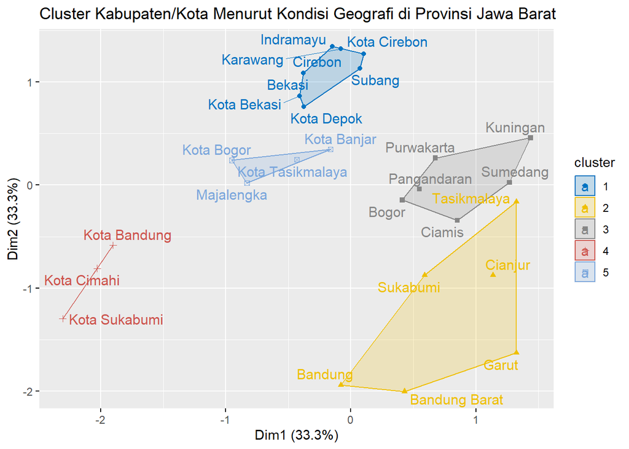

```r
# plotcluster(fcm_4, cp = 1, trans = TRUE)
res.fcm4 <- ppclust2(fcm_4, "fanny")
# res.fcm2

fviz_cluster(res.fcm4, data=PCA_scores, palette="jco", repel=TRUE, main = "Cluster Kabupaten/Kota Menurut Kondisi Geografi di Provinsi Jawa Barat")
```

#### Jumlah cluster = 5, fuzzifier = 1.5

```r
res.fcm1 = ppclust2(fcm_1, "fclust")

#install.packages("Rcpp")
library(Rcpp)
library(fclust)
# 1. FUZZY SILHOUETTE INDEX
fsi = SIL.F(res.fcm1$Xca, res.fcm1$U, alpha=1)
paste("Fuzzy Silhouette Index:", fsi)
```

```
## [1] "Fuzzy Silhouette Index: 0.675574529586188"
```

```r
# 2. PARTITION ENTROPY
pe <- PE(res.fcm1$U)
paste("Partition Entropy: ", pe)
```

```
## [1] "Partition Entropy:  0.213593970998746"
```

```r
# 3. Partition Coefficient:
pc <- PC(res.fcm1$U)
paste("Partition Coefficient : ", pc)
```

```
## [1] "Partition Coefficient :  0.905463762120998"
```

```r
# 4. Modified Partition Coefficient:
mpc <- MPC(res.fcm1$U)
paste("Modified Partition Coefficient : ", mpc)
```

```
## [1] "Modified Partition Coefficient :  0.881829702651248"
```

#### Jumlah cluster = 5, Fuzzifier m = 2

```r
res.fcm2 = ppclust2(fcm_2, "fclust")
#install.packages("Rcpp")
library(Rcpp)
library(fclust)
# 1. FUZZY SILHOUETTE INDEX
fsi = SIL.F(res.fcm2$Xca, res.fcm2$U, alpha=1)
paste("Fuzzy Silhouette Index:", fsi)
```

```
## [1] "Fuzzy Silhouette Index: 0.70588211525593"
```

```r
# 2. PARTITION ENTROPY
pe <- PE(res.fcm2$U)
paste("Partition Entropy: ", pe)
```

```
## [1] "Partition Entropy:  0.669482870570076"
```

```r
# 3. Partition Coefficient:
pc <- PC(res.fcm2$U)
paste("Partition Coefficient : ", pc)
```

```
## [1] "Partition Coefficient :  0.682168364834897"
```

```r
# 4. Modified Partition Coefficient:
mpc <- MPC(res.fcm2$U)
paste("Modified Partition Coefficient : ", mpc)
```

```
## [1] "Modified Partition Coefficient :  0.602710456043622"
```

#### Jumlah cluster = 5, Fuzzifier m = 2.5

```r
res.fcm3 = ppclust2(fcm_3, "fclust")
#install.packages("Rcpp")
library(Rcpp)
library(fclust)
# 1. FUZZY SILHOUETTE INDEX
fsi = SIL.F(res.fcm3$Xca, res.fcm3$U, alpha=1)
paste("Fuzzy Silhouette Index:", fsi)
```

```
## [1] "Fuzzy Silhouette Index: 0.745081065305097"
```

```r
# 2. PARTITION ENTROPY
pe <- PE(res.fcm3$U)
paste("Partition Entropy: ", pe)
```

```
## [1] "Partition Entropy:  0.967612404371934"
```

```r
# 3. Partition Coefficient:
pc <- PC(res.fcm3$U)
paste("Partition Coefficient : ", pc)
```

```
## [1] "Partition Coefficient :  0.534863858672709"
```

```r
# 4. Modified Partition Coefficient:
mpc <- MPC(res.fcm3$U)
paste("Modified Partition Coefficient : ", mpc)
```

```
## [1] "Modified Partition Coefficient :  0.418579823340887"
```

#### Jumlah cluster = 5, Fuzzifier m = 3

```r
res.fcm4 = ppclust2(fcm_4, "fclust")
#install.packages("Rcpp")
library(Rcpp)
library(fclust)
# 1. FUZZY SILHOUETTE INDEX
fsi = SIL.F(res.fcm4$Xca, res.fcm4$U, alpha=1)
paste("Fuzzy Silhouette Index:", fsi)
```

```
## [1] "Fuzzy Silhouette Index: 0.458902738718256"
```

```r
# 2. PARTITION ENTROPY
pe <- PE(res.fcm4$U)
paste("Partition Entropy: ", pe)
```

```
## [1] "Partition Entropy:  1.22320073600299"
```

```r
# 3. Partition Coefficient:
pc <- PC(res.fcm4$U)
paste("Partition Coefficient : ", pc)
```

```
## [1] "Partition Coefficient :  0.399731744261792"
```

```r
# 4. Modified Partition Coefficient:
mpc <- MPC(res.fcm4$U)
paste("Modified Partition Coefficient : ", mpc)
```

```
## [1] "Modified Partition Coefficient :  0.24966468032724"
```

#### Yang terpilih k = 5; m = 1.5

```r
data_fcm_5_1 <- cbind(mydata, fcm_1$cluster)
colnames(data_fcm_5_1)[14] <- "cluster"
```

## DB-SCAN CLUSTERING

### Cluster number optimal

```r
# install.packages("dbscan")
library(dbscan)
```

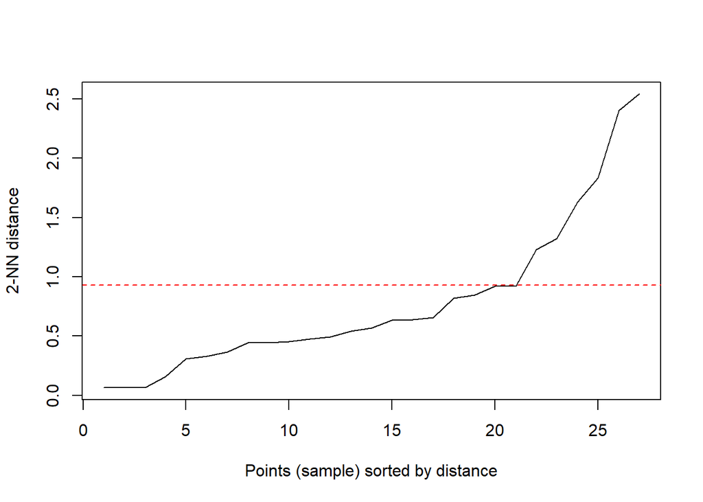

```
## integer(0)
```

```r
kNNdistplot(PCA_scores, k = 2) + abline(h =  0.93, col = "red", lty = 2)
```

```r
# Menentukan parameter untuk DBSCAN
epsilon <- 0.93  # Radius untuk mencari tetangga
minPts <- 2  # Jumlah titik minimum untuk membentuk klaster

# Melakukan klastering dengan DBSCAN
dbscan_result <- dbscan(PCA_scores, eps = epsilon, minPts = minPts)
dbscan_result
```

```
## DBSCAN clustering for 27 objects.
## Parameters: eps = 0.93, minPts = 2
## Using euclidean distances and borderpoints = TRUE
## The clustering contains 3 cluster(s) and 4 noise points.
##
##  0  1  2  3
##  4 18  2  3
##
## Available fields: cluster, eps, minPts, dist, borderPoints
```

```r
# Mengambil indeks klaster dan k-tetangga terdekat dari setiap titik
cluster_indices <- dbscan_result$cluster

# sc_data_db <- sc_data_db %>%
#   mutate(clust = ifelse(clust == "Noise", 3, clust))

# visualisasi
data_db <- as.data.frame(PCA_scores) %>%
  mutate(clust = dbscan_result$cluster,
         clust = ifelse(clust=="Noise",0,clust))
data_db
```

```
##                          PC1         PC2         PC3 clust
## Bandung          -2.86179199  0.71050404 -0.52052425     0
## Bandung Barat    -2.95453318 -1.25789640  1.17965434     0
## Bekasi            1.60561638 -0.53305643 -0.01129065     1
## Bogor            -0.21517869  0.08099699  0.32310634     1
## Ciamis           -0.50559775  0.33144265  0.56553025     1
## Cianjur          -1.29292433  0.63320935  0.63341060     1
## Cirebon           1.94857584 -0.37681863  0.16372552     1
## Garut            -2.40348161  0.97048093  0.59064463     0
## Indramayu         1.98715583 -0.41306740  0.12590299     1
## Karawang          1.95150693 -0.37847057  0.16533720     1
## Kota Bandung     -0.86207637 -0.63278342 -1.32927963     2
## Kota Banjar       0.50979477 -0.42626224  0.12005640     1
## Kota Bekasi       1.27650816 -0.53684728 -0.03339684     1
## Kota Bogor        0.35409566 -0.61250241 -0.48004317     1
## Kota Cimahi      -1.19468063 -0.65318381 -1.43141328     2
## Kota Cirebon      1.88015830 -0.29295783  0.27812823     1
## Kota Depok        1.12101156 -0.46646600 -0.04860761     1
## Kota Sukabumi    -1.91297172 -2.82282354 -0.31897361     0
## Kota Tasikmalaya  0.36316381 -0.23441504 -0.24576121     1
## Kuningan          0.67576806  2.47944938 -0.25312328     3
## Majalengka        0.02811576 -0.64412905 -0.34987801     1
## Pangandaran      -0.05905147 -0.01583839  0.50774305     1
## Purwakarta        0.38694030  0.14639479  0.52106488     1
## Subang            1.66994360 -0.27857407  0.24280326     1
## Sukabumi         -1.29286742  0.31083988  0.33875080     1
## Sumedang          0.03716418  2.47915297 -0.40574432     3
## Tasikmalaya      -0.24036399  2.43362152 -0.32782264     3
```

```r
# membuat kolom baru untuk cluster
ready_data <- ready_data %>%
  mutate(clust = data_db$clust)
ready_data %>% count("clust")
```

```
##   "clust"  n
## 1   clust 27
```

```r
# membuat pallet color untuk setiap cluster
library(fishualize)
library(leaflet)
pallet <- fishualize::fish(n = length(unique(ready_data$clust)), option = "Coris_gaimard", end = 0.9)
# ?fishualize::fish()
# ?colorFactor()
pal <- colorFactor(pallet, domain = unique(ready_data$clust))

# Visualisasi cluster dengan tooltip yang muncul saat dihover
leaflet(data = ready_data) %>%
  addTiles() %>%
  setView(lng = 107, lat = -7, zoom = 7) %>%
  addCircleMarkers(lng = ~long,
                   lat = ~lat,
                   radius = 15,
                   color = ~pal(clust),
                   label = ~paste("Nama Kab/Kota: ", rownames(ready_data)),
                   labelOptions = labelOptions(noHide = FALSE, direction = "auto"))
```

[interactive chart not shown]